# Project3

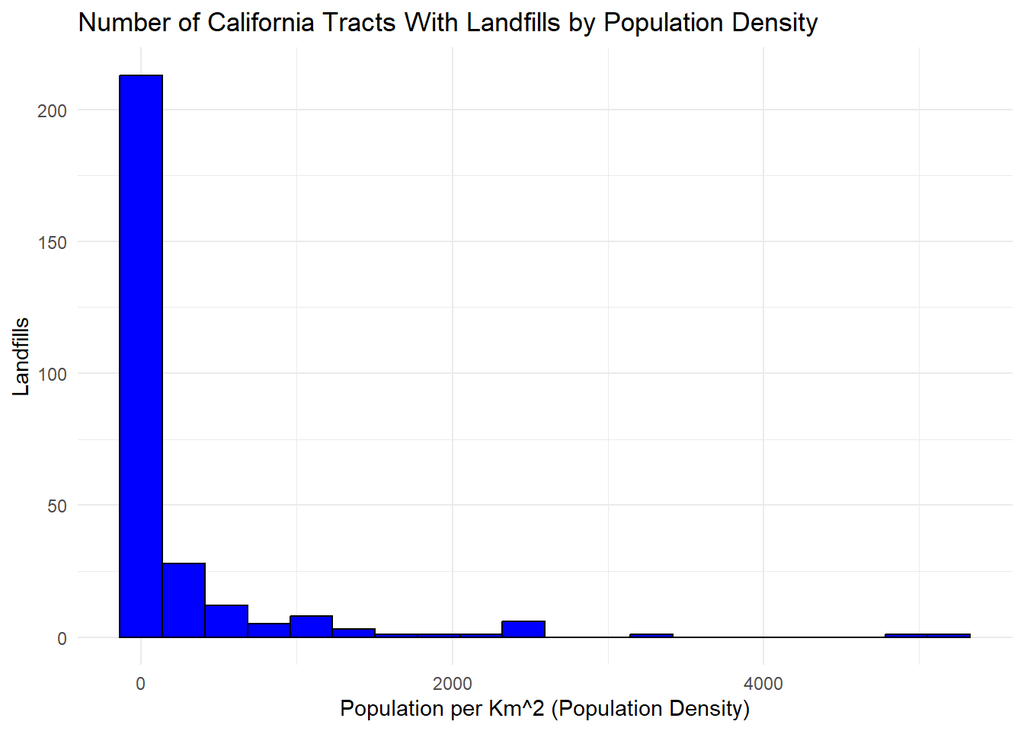

```r
#These two ggplot blocks Frequency Histograms for number of tracts with landfills by population density
ggplot(trashCATT, aes(x = as.numeric(pop_density))) +
  geom_histogram(
    bins = 20,
    fill = "blue",
    color = "black"
  ) +
  labs(
    x = "Population per Km^2 (Population Density)",
    y = "Landfills",
    title = "Number of California Tracts With Landfills by Population Density"
  ) +
  theme_minimal()
```

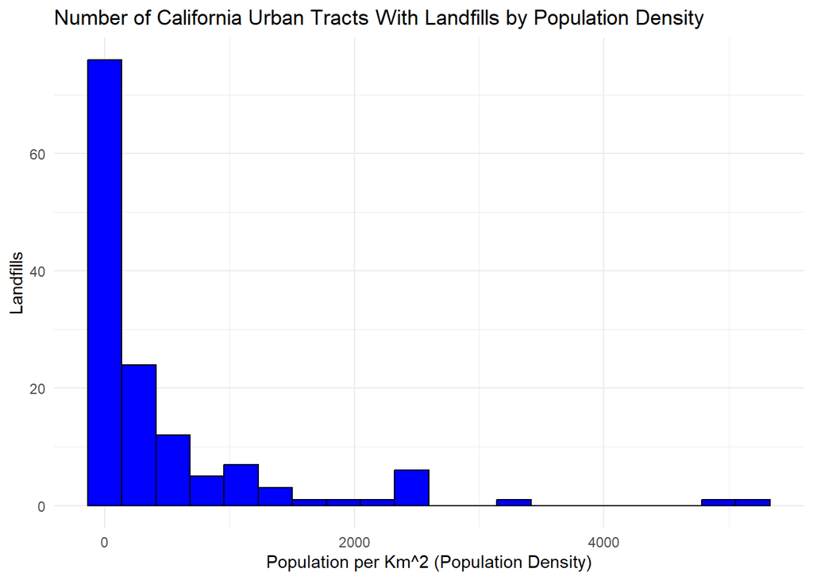

```r
ggplot(trashCATUT, aes(x = as.numeric(pop_density))) +
  geom_histogram(
    bins = 20,
    fill = "blue",
    color = "black"
  ) +
  labs(
    x = "Population per Km^2 (Population Density)",
    y = "Landfills",
    title = "Number of California Urban Tracts With Landfills by Population Density"
  ) +
  theme_minimal()
```

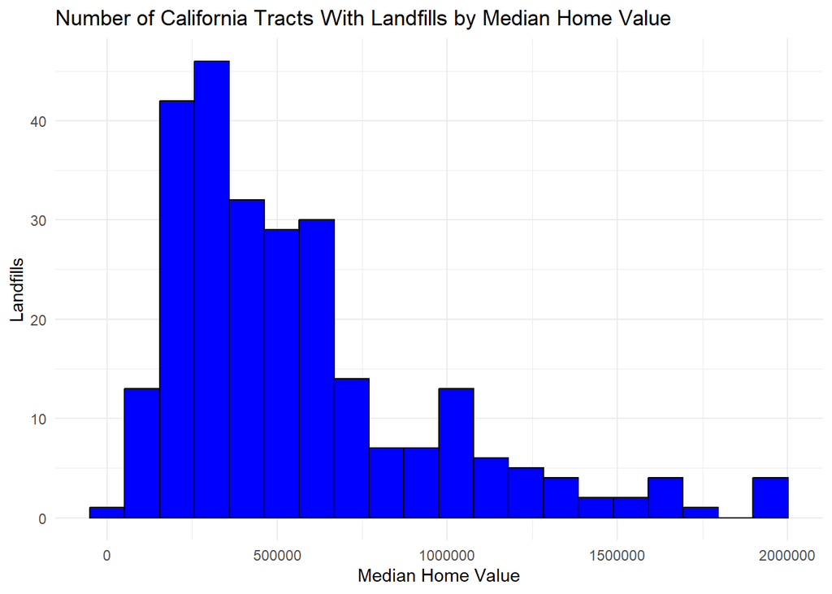

```r
#These two ggplot blocks Frequency Histograms for number of tracts with landfills by median home value
ggplot(trashCATT, aes(x = as.numeric(med_home_valE))) +
  geom_histogram(
    bins = 20,
    fill = "blue",
    color = "black"
  ) +
  labs(
    x = "Median Home Value",
    y = "Landfills",
    title = "Number of California Tracts With Landfills by Median Home Value"
  ) +
  theme_minimal()
```

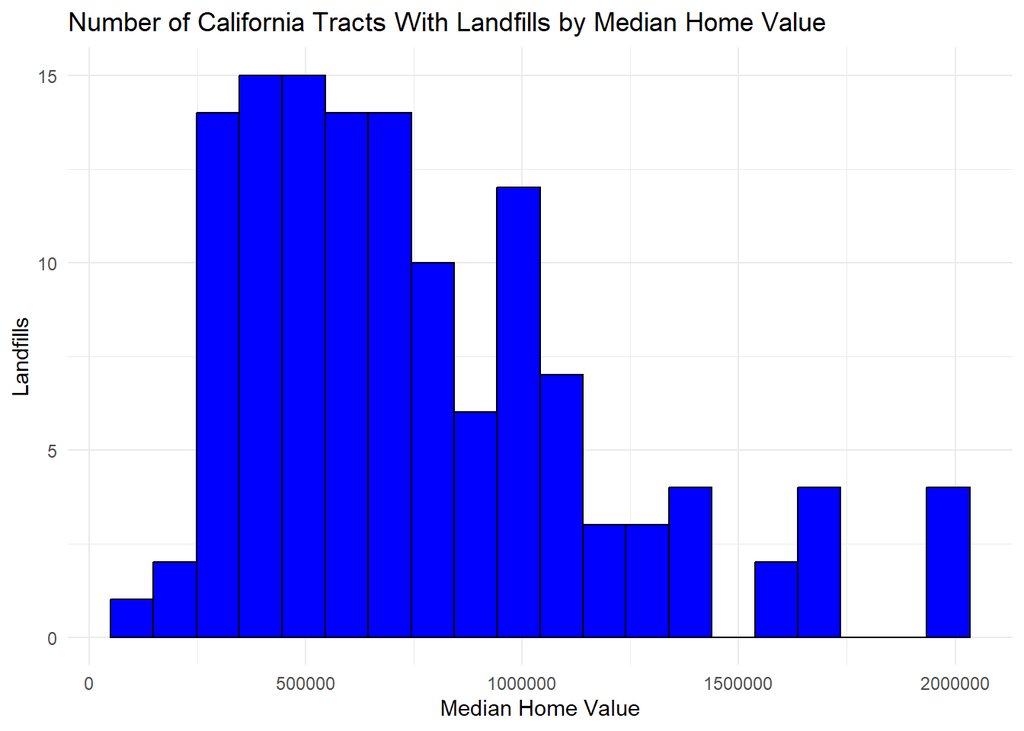

```r
ggplot(trashCATUT, aes(x = as.numeric(med_home_valE))) +
  geom_histogram(
    bins = 20,
    fill = "blue",
    color = "black"
  ) +
  labs(
    x = "Median Home Value",
    y = "Landfills",
    title = "Number of California Tracts With Landfills by Median Home Value"
  ) +
  theme_minimal()
```

For data visualization I chose to use histograms to best represent the continuous independent variables being measured here, with the number of landfill’s for each bin represented on the Y-axis. This should give a good idea of the distribution of landfills among different values for each variable.

#### 3.33 Mapping

```
## [v3->v4] `tm_add_legend()`: use `type = "symbols"` instead of `type =
## "symbol"`.
```

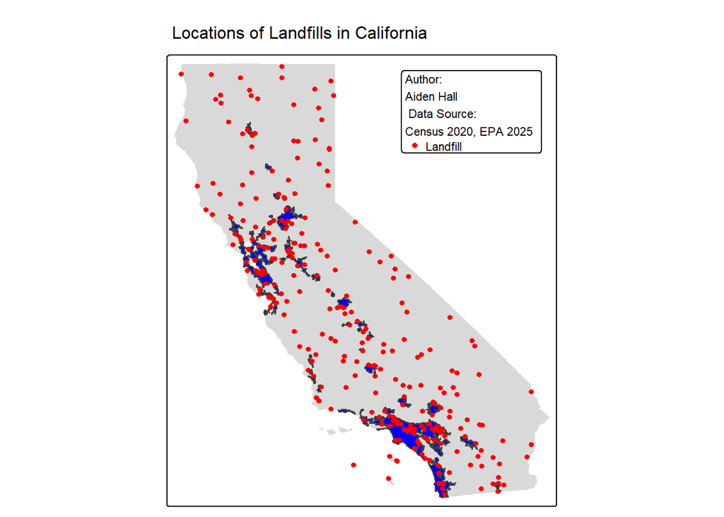

```r
#Creates a map of all CA landfills with Urban area boundaries that intersect with the state of california. Some are mostly not located in the state of california.
  tm_shape(ca_tracts) +
  tm_polygons(col=NULL)+
  tm_shape(urban_areasCA)+
  tm_polygons(fill = "blue")+
  tm_shape(trashCA)+
  tm_dots(fill = "red")+tm_title("Locations of Landfills in California")+
  tm_credits(paste("Author: \nAiden Hall\n","Data Source: \nCensus 2020, EPA 2025"), position = c("right","top"))+
   tm_layout(
    title.size = 1,
    legend.height = 1,
   legend.width = 1,
  )+
  tm_add_legend(type = "symbol",
              labels = "Landfill",
              fill = "red",
              shape = 16,
              size = 0.35,
              position = c("right", "top"))
```

Because tracts are so small that doing visual mapping analysis of individual tracts at a state level is impractical, further mapping analysis will focus on a couple urban areas. This map shows the location of all landfills in California, so that clusters can be identified and then shown closer up in greater detail. The map shows that there are substantial clusters in the San Jose and Los Angeles urban areas (I identified them independently due to issues with names covering each other up on the map if used).

```r
#Creates a subset of tracts and trash points for San Jose
SJ_Area <- urban_areasCA |>
  filter(GEOID10 == 79039)
SJ_tracts  <- ca_tracts |>
  st_filter(SJ_Area)
SJ_trash <- trashCA |>
  st_filter(SJ_Area)

#Creates a subset of tracts and trash points for LA
la_Area <- urban_areasCA |>
  filter(GEOID10 == 51445)
la_tracts  <- ca_tracts |>
  st_filter(la_Area)
la_trash <- trashCA |>
  st_filter(la_Area)
```

I chose to focus on LA and San Jose in my more focused mapping analysis to demonstrate the general trend of landfill locations in cities. This was due to the identified clusters in the map above. This block of code uses the urban geometries for these two areas to spatially filter tracts and landfill locations to create one map. One limitation of this method is that some rural tracts that barely intersect with the urban areas are represented.

[output not shown]

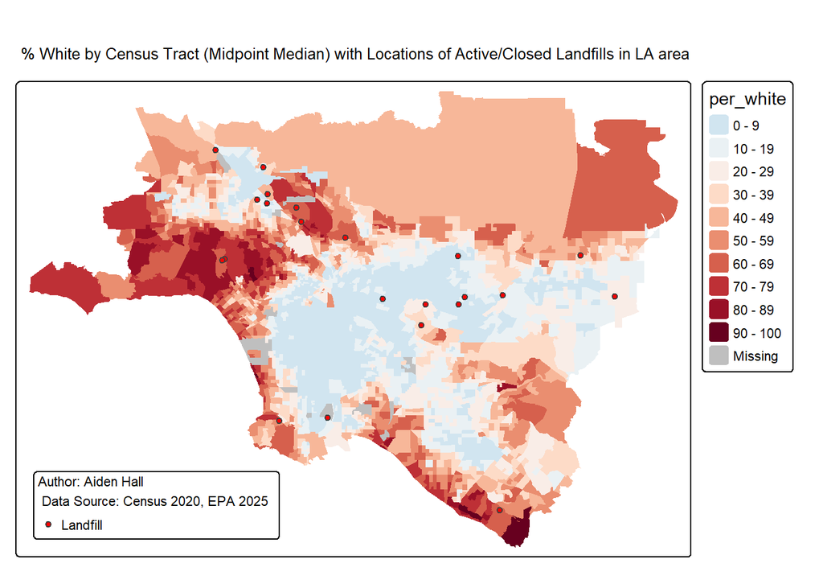

```r
#WHITE PERCENT MAPS

#Finds the median value of percentage of white people in tracts, which is 19.63, rounded up to 20
La_Med_White <- median(la_tracts$per_white, na.rm = TRUE)

#Makes a map of LA area using census tracts with white percentage fill, with a break on the median percentage of white
tm_shape(la_tracts) +
  tm_polygons(
    fill = "per_white", col=NULL,
    fill.scale = tm_scale_intervals(
      breaks = c(0,10,20,30,40,50,60,70,80,90,100),
      midpoint = 20,
values = rev(RColorBrewer::brewer.pal(n = 11, name = "RdBu"))
  ) )+
  tm_shape(la_trash)+
  tm_dots(fill="red",
          color = "black",
          shape = 21,
          size = 0.35)+  tm_title("% White by Census Tract (Midpoint Median) with Locations of Active/Closed Landfills in LA area")+
  tm_credits(paste("Author: Aiden Hall\n","Data Source: Census 2020, EPA 2025"), position = c("left","bottom"))+
   tm_layout(
    title.size = 1
  ) +tm_add_legend(type = "symbol",
              labels = "Landfill",
              fill = "red",
              color = "black",
              lwd = 1,
              shape = 21,
              size = 0.35,
              position = c("left", "bottom"))
```

[output not shown]

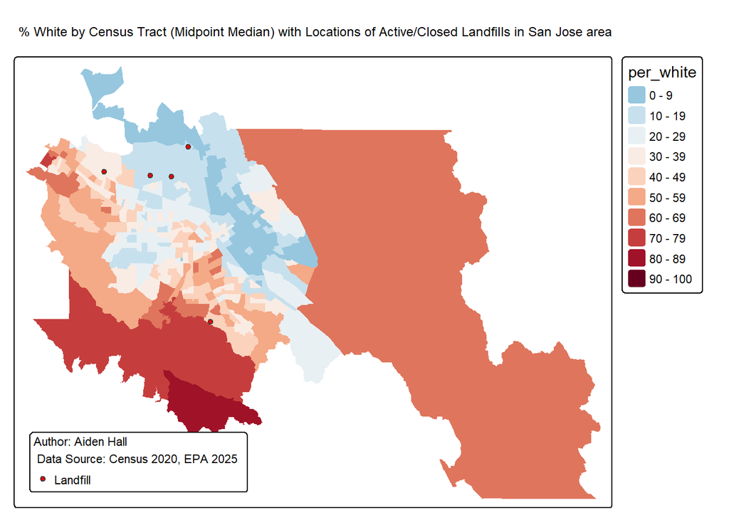

```r
#Finds median white percentage among census tracts in San Jose
SJ_Med_White <- median(SJ_tracts$per_white, na.rm = TRUE)

#Makes a map of San Jose using census tracts with white percentage fill, with a break on the median percentage of white
tm_shape(SJ_tracts) +
  tm_polygons(
    fill = "per_white", col=NULL,
    fill.scale = tm_scale_intervals(
      breaks = c(0,10,20,30,40,50,60,70,80,90,100),
      midpoint = 30,
values = rev(RColorBrewer::brewer.pal(n = 11, name = "RdBu"))
  ) )+
  tm_shape(SJ_trash)+
  tm_dots(fill="red",
          color = "black",
          shape = 21,
          size = 0.35)+  tm_title("% White by Census Tract (Midpoint Median) with Locations of Active/Closed Landfills in San Jose area")+
  tm_credits(paste("Author: Aiden Hall\n","Data Source: Census 2020, EPA 2025"), position = c("left","bottom"))+
   tm_layout(
    title.size = 1
  ) +tm_add_legend(type = "symbol",
              labels = "Landfill",
              fill = "red",
              color = "black",
              lwd = 1,
              shape = 21,
              size = 0.35,
              position = c("left", "bottom"))
```

[output not shown]

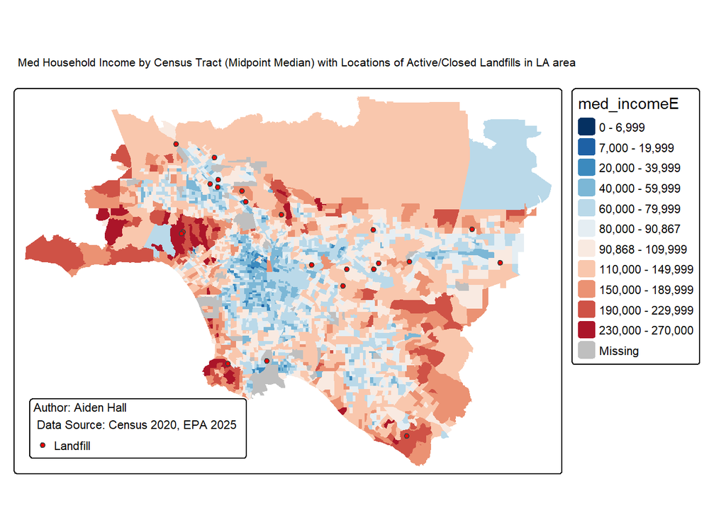

```r
#INCOME MAPS

#Calculate median income for LA
La_Med_Income <- median(la_tracts$med_incomeE, na.rm = TRUE)

#Makes map of LA census tracts with data on median household income
tm_shape(la_tracts) +
  tm_polygons(
    fill = "med_incomeE", col=NULL,
    fill.scale = tm_scale_intervals(
      breaks = c(0,7000,20000,40000,60000,80000,90868,110000,150000,190000,230000,270000),
      midpoint = 90868,
values = rev(RColorBrewer::brewer.pal(n = 11, name = "RdBu"))
  ) )+
  tm_shape(la_trash)+
  tm_dots(fill="red",
          color = "black",
          shape = 21,
          size = 0.35)+  tm_title("Med Household Income by Census Tract (Midpoint Median) with Locations of Active/Closed Landfills in LA area")+
  tm_credits(paste("Author: Aiden Hall\n","Data Source: Census 2020, EPA 2025"), position = c("left","bottom"))+
   tm_layout(
    title.size = 1
  ) +tm_add_legend(type = "symbol",
              labels = "Landfill",
              fill = "red",
              color = "black",
              lwd = 1,
              shape = 21,
              size = 0.35,
              position = c("left", "bottom"))
```

[output not shown]

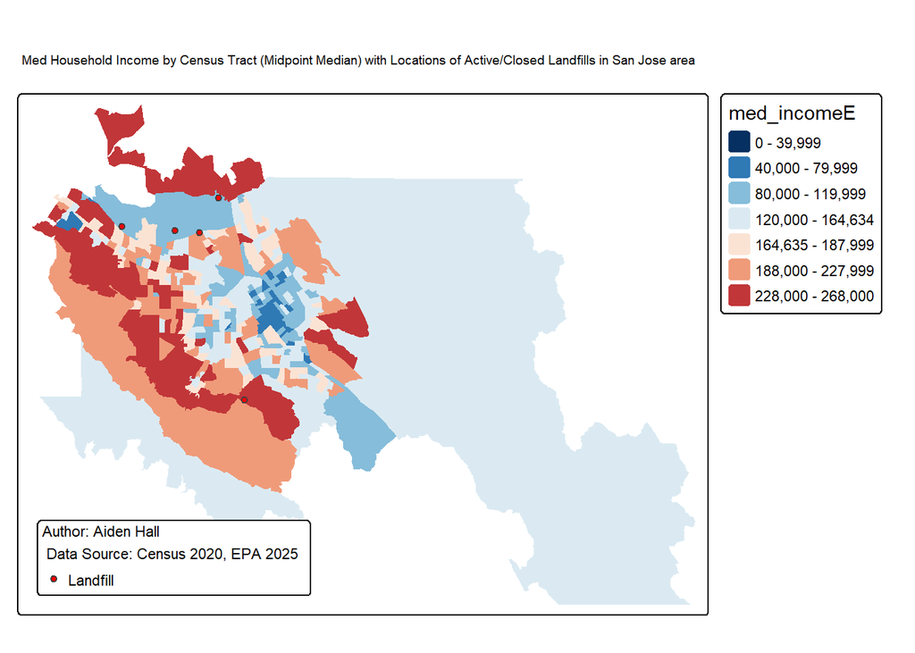

```r
#Calculate median income for LA
SJ_Med_Income <- median(SJ_tracts$med_incomeE, na.rm = TRUE)

#Makes a map of San Jose using census tracts with med household income fill, with a break on the median percentage of white
tm_shape(SJ_tracts) +
  tm_polygons(
    fill = "med_incomeE", col=NULL,
    fill.scale = tm_scale_intervals(
      breaks = c(0,40000,80000,120000,164635,188000,228000,268000),
      midpoint = 164635,
values = rev(RColorBrewer::brewer.pal(n = 11, name = "RdBu"))
  ) )+
  tm_shape(SJ_trash)+
  tm_dots(fill="red",
          color = "black",
          shape = 21,
          size = 0.35)+  tm_title("Med Household Income by Census Tract (Midpoint Median) with Locations of Active/Closed Landfills in San Jose area")+
  tm_credits(paste("Author: Aiden Hall\n","Data Source: Census 2020, EPA 2025"), position = c("left","bottom"))+
   tm_layout(
    title.size = 1
  ) +tm_add_legend(type = "symbol",
              labels = "Landfill",
              fill = "red",
              color = "black",
              lwd = 1,
              shape = 21,
              size = 0.35,
              position = c("left", "bottom"))
```

[output not shown]

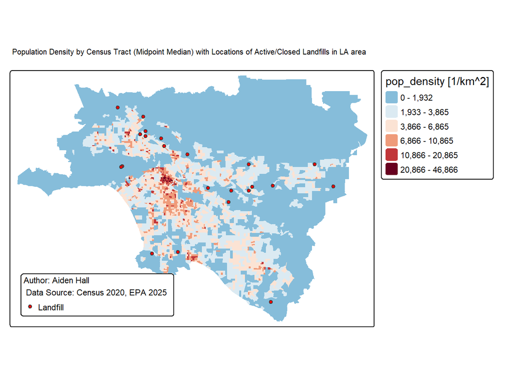

```r
#Density Maps

#Calculates the median population density of La
La_Med_Density <- median(la_tracts$pop_density, na.rm = TRUE)

tm_shape(la_tracts) +
  tm_polygons(
    fill = "pop_density", col=NULL,
    fill.scale = tm_scale_intervals(
      breaks = c(0,1933,3866,6866,10866,20866,46866),
      midpoint = 3866,
values = rev(RColorBrewer::brewer.pal(n = 11, name = "RdBu"))
  ) )+
  tm_shape(la_trash)+
  tm_dots(fill="red",
          color = "black",
          shape = 21,
          size = 0.35)+  tm_title("Population Density by Census Tract (Midpoint Median) with Locations of Active/Closed Landfills in LA area")+
  tm_credits(paste("Author: Aiden Hall\n","Data Source: Census 2020, EPA 2025"), position = c("left","bottom"))+
   tm_layout(
    title.size = 1
  ) +tm_add_legend(type = "symbol",
              labels = "Landfill",
              fill = "red",
              color = "black",
              lwd = 1,
              shape = 21,
              size = 0.35,
              position = c("left", "bottom"))
```

[output not shown]

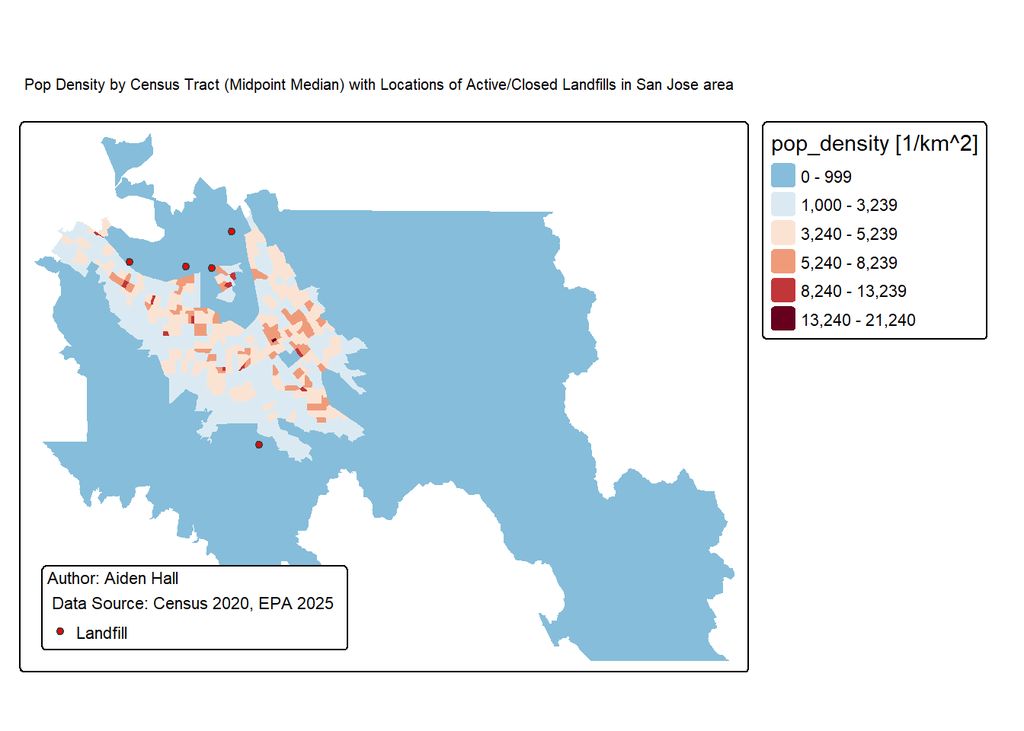

```r
#Calculates the median population density of San Jose
SJ_Med_Density <- median(SJ_tracts$pop_density, na.rm = TRUE)


#Makes a map of San Jose using census tracts with pop density fill, with a break on the median percentage of white
tm_shape(SJ_tracts) +
  tm_polygons(
    fill = "pop_density", col=NULL,
    fill.scale = tm_scale_intervals(
      breaks = c(0,1000,3240,5240,8240,13240,21240),
      midpoint = 3240,
values = rev(RColorBrewer::brewer.pal(n = 11, name = "RdBu"))
  ) )+
  tm_shape(SJ_trash)+
  tm_dots(fill="red",
          color = "black",
          shape = 21,
          size = 0.35)+  tm_title("Pop Density by Census Tract (Midpoint Median) with Locations of Active/Closed Landfills in San Jose area")+
  tm_credits(paste("Author: Aiden Hall\n","Data Source: Census 2020, EPA 2025"), position = c("left","bottom"))+
   tm_layout(
    title.size = 1
  ) +tm_add_legend(type = "symbol",
              labels = "Landfill",
              fill = "red",
              color = "black",
              lwd = 1,
              shape = 21,
              size = 0.35,
              position = c("left", "bottom"))
```